# Estimación no paramétrica

Authors

Affiliations

Félix Belzunce

Universidad de Murcia

María del Carmen Bueso, Pilar Sanmartín

Universidad Politécnica de Cartagena

# Introducción

El objetivo de esta práctica es presentar en `R` las herramientas estadísticas para la estimación de la función de distribución y la función de densidad. Como hemos comentado en clase, la estimación de la función puntual de probabilidad se realiza a través de las correspondientes proporciones muestrales. Recordamos que la estimación de la función de distribución se realiza a través de la función de distribución empírica y la estimación de la función de densidad a través de los estimadores tipo núcleo.

# Función de distribución empírica

Dada una variable aleatoria $X$ con función de distribución $F(x)=P(X\le x)$, tenemos que el estimador de $F$ es la *función de distribución empírica* que viene dada por
$$F_n(x)=\frac{\sum_{i=1}^n I_{(-\infty,x]}(X_i)}{n} \text{ para todo }x\in \mathbb R,$$
dada un m.a.s., $X_1,\ldots,X_n$, de $X$.

Veamos como está implementado su cálculo en `R`. La función que utilizaremos es la función `ecdf`.

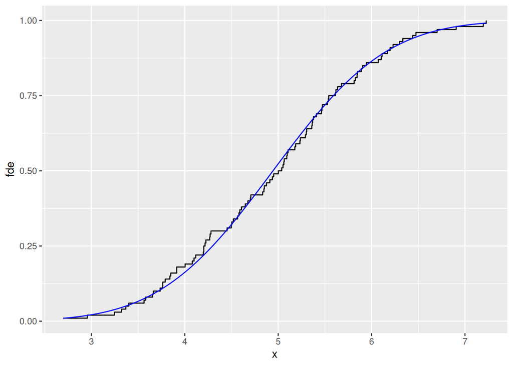

```r
# Completar aquí

# Cargar librería necesaria
library(ggplot2)

# Generar una muestra aleatoria (ejemplo: n=100 de N(5, 1))
set.seed(314159)  # Para reproducibilidad
n <- 100
datos <- rnorm(n, mean = 5, sd = 1)

# Calcular la función de distribución empírica (FDE)
fde <- ecdf(datos)

# Crear un vector de puntos x donde evaluar la FDE y la teórica
x_vals <- seq(min(datos), max(datos), length.out = 1000)

# Evaluar la FDE en esos puntos
y_fde <- fde(x_vals)

# Evaluar la función de distribución teórica (normal con media y desv. est. muestrales)
y_teorica <- pnorm(x_vals, mean = mean(datos), sd = sd(datos))

# Crear un data frame para ggplot2
df_plot <- data.frame(
  x = x_vals,
  fde = y_fde,
  teorica = y_teorica
)

# Graficar
ggplot(df_plot, aes(x = x)) +
  geom_step(aes(y = fde), color = "black", linetype = "solid") +  # Escalera (step function)
  geom_line(aes(y = teorica), color = "blue")
```

```r
# Fin Completar aquí
```

Podemos ver en este caso la buena aproximación de la distribución teórica a través de la función de distribución empírica.

# Estimación tipo núcleo

Siguiendo la notación anterior, en este caso se trata de estimar la función de densidad, $f(x)=F'(x)$, de la variable $X$.

Los estimadores de la función de densidad vistos en clase se conocen como *estimadores tipo núcleo* y su expresión general viene dada por
$$\hat f_n(x)=\frac{1}{2nh_n}\sum_{i=1}^n K\left(\frac{x-X_i}{h_n}\right),$$
donde $K$ es una función núcleo y $h_n$ es lo que se conoce como el ancho de banda.

Veamos como obtener este estimador con `R` para diferentes núcleos y diferentes anchos de banda. La función que nos permite obtener la estimación tipo núcleo es `density`.

Recordamos que los núcleos vistos en teoría:

- **Núcleo rectangular:** $K$ es la función de densidad de una distribución uniforme.
- **Núcleo normal:** $K$ es la función de densidad de una distribución normal estándar. Suele ser el núcleo que más se utiliza.
- **Núcleo de Epanechnikov:** $K(z)=(1-z^2)I_{(-1,1)}$. Se considera que es el núcleo más eficiente.

donde estos dos últimos son los más utilizados.

Veamos un ejemplo con cada núcleo.

- Núcleo rectangular:

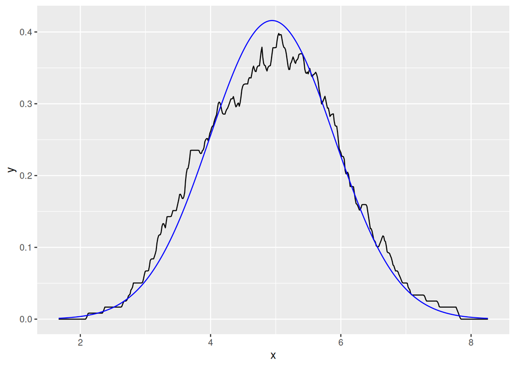

```r
# Completar aquí

# Estimar densidad con núcleo rectangular
dens_rect <- density(datos, kernel = "rectangular", bw = "nrd0")

# Crear un data frame para ggplot2
df_dens <- data.frame(
  x = dens_rect$x,
  y_rect = dens_rect$y
)

# Calcular la densidad teórica (normal con media y desv. est. muestrales)
df_dens$y_teorica <- dnorm(df_dens$x, mean = mean(datos), sd = sd(datos))

# Graficar
ggplot(df_dens, aes(x = x)) +
  geom_line(aes(y = y_rect)) +
  geom_line(aes(y = y_teorica), color = "blue") +
  labs(x = "x", y = "y")
```

```r
# Fin Completar aquí
```

- Núcleo normal:

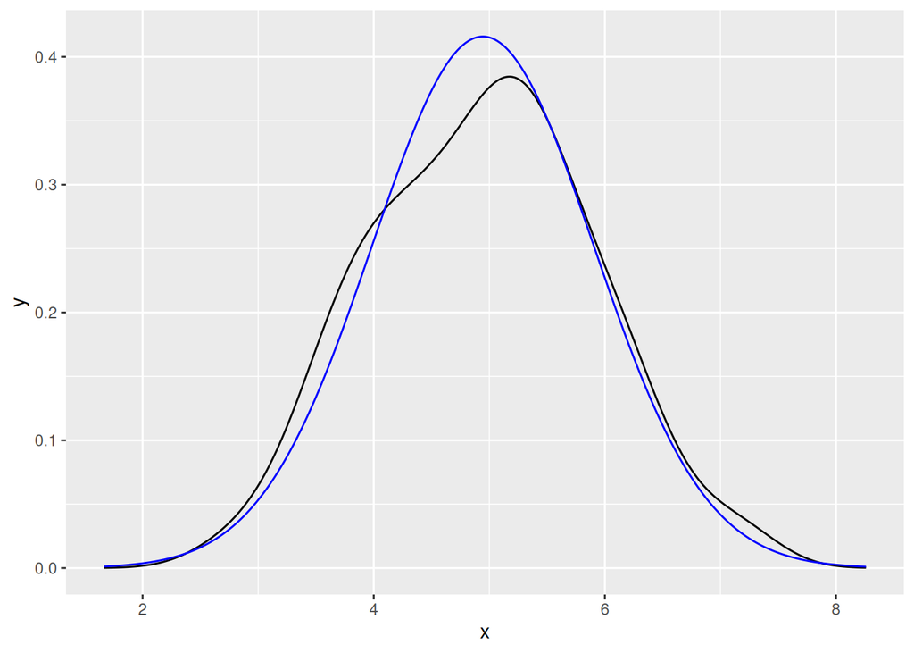

```r
# Completar aquí

# Estimar densidad con núcleo normal
dens_gauss <- density(datos, kernel = "gaussian", bw = "nrd0")

# Crear un data frame para ggplot2
df_dens <- data.frame(
  x = dens_gauss$x,
  y_gauss = dens_gauss$y
)

# Calcular la densidad teórica (normal con media y desv. est. muestrales)
df_dens$y_teorica <- dnorm(df_dens$x, mean = mean(datos), sd = sd(datos))

# Graficar
ggplot(df_dens, aes(x = x)) +
  geom_line(aes(y = y_gauss), color = "black", linetype = "solid") +
  geom_line(aes(y = y_teorica), color = "blue") +
  labs(x = "x", y = "y")
```

```r
# Fin Completar aquí
```

- Para el caso del núcleo de Epanechnikov tendríamos:

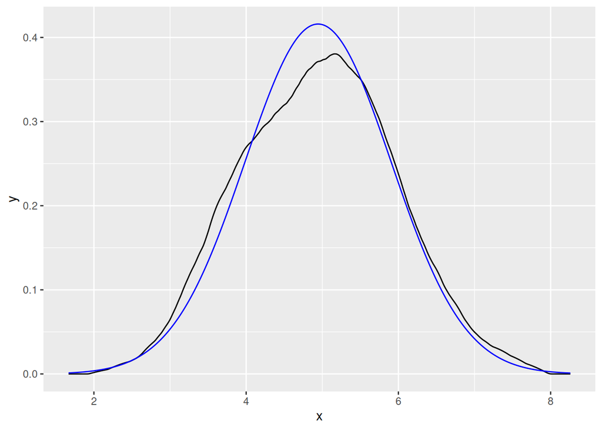

```r
# Completar aquí
 # Estimar densidad con núcleo Epanechnikov
dens_epan <- density(datos, kernel = "epanechnikov", bw = "nrd0")

# Crear un data frame para ggplot2
df_dens <- data.frame(
  x = dens_epan$x,
  y_epan = dens_epan$y
)

# Calcular la densidad teórica (normal con media y desv. est. muestrales)
df_dens$y_teorica <- dnorm(df_dens$x, mean = mean(datos), sd = sd(datos))

# Graficar
ggplot(df_dens, aes(x = x)) +
  geom_line(aes(y = y_epan), color = "black", linetype = "solid") +
  geom_line(aes(y = y_teorica), color = "blue") +
  labs(x = "x", y = "y")
```

```r
# Fin Completar aquí
```

Como vemos, sobre todo en los dos tipos últimos casos, hay una aproximación bastante buena entre el valor real y la aproximación mediante el estimador tipo núcleo. Nos vamos a centrar en el estudio del núcleo normal y el de Epanechnikov.

La elección del ancho de banda se basa en la fórmula general:
$$h_n=\left( \frac{R(K)}{\mu_2^2(K)R(f'')n} \right)^{\frac{1}{5}},$$
donde los valores $R(K)$ y $\mu_2(K)$ dependen del núcleo $K$ y $R(f'')$ depende de la función de densidad de la variable (ver los detalles en los apuntes del tema). Esto último presenta un problema ya que el término $R(f'')$ depende de la función de densidad que es desconocida y por tanto no se pude calcular su valor exacto.

La forma más complicada de evaluar es dando una estimación no paramétrica de $R(f'')$. La metodología va más allá de los contenidos de esta asignatura y no veremos los detalles, solo indicar que podemos seleccionarla en el argumento `bw` como `"SJ"`.

Vamos a reproducir las gráficas de antes con esta elección del ancho de banda.

Caso con núcleo normal:

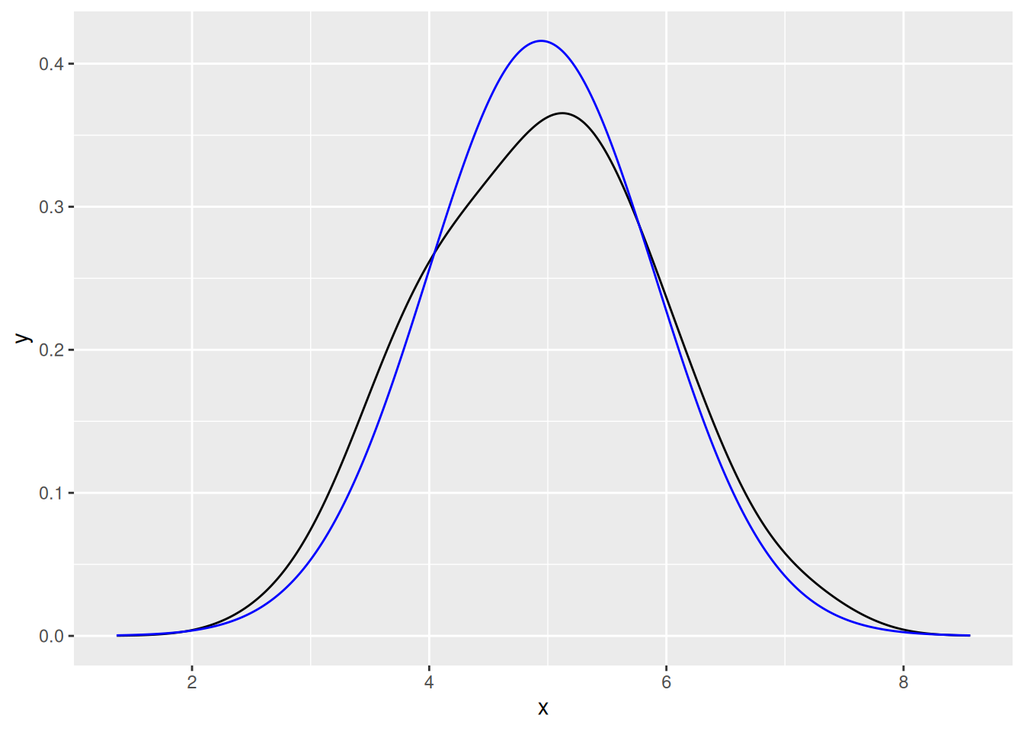

```r
# Completar aquí
# Estimar densidad con núcleo normal y ancho de banda SJ
dens_gauss_sj <- density(datos, kernel = "gaussian", bw = "SJ")

# Crear un data frame para ggplot2
df_dens <- data.frame(
  x = dens_gauss_sj$x,
  y_gauss_sj = dens_gauss_sj$y
)

# Calcular la densidad teórica (normal con media y desv. est. muestrales)
df_dens$y_teorica <- dnorm(df_dens$x, mean = mean(datos), sd = sd(datos))

# Graficar
ggplot(df_dens, aes(x = x)) +
  geom_line(aes(y = y_gauss_sj), color = "black", linetype = "solid") +
  geom_line(aes(y = y_teorica), color = "blue") +
  labs(x = "x", y = "y")
```

```r
# Fin Completar aquí
```

Caso con núcleo Epanechnivok:

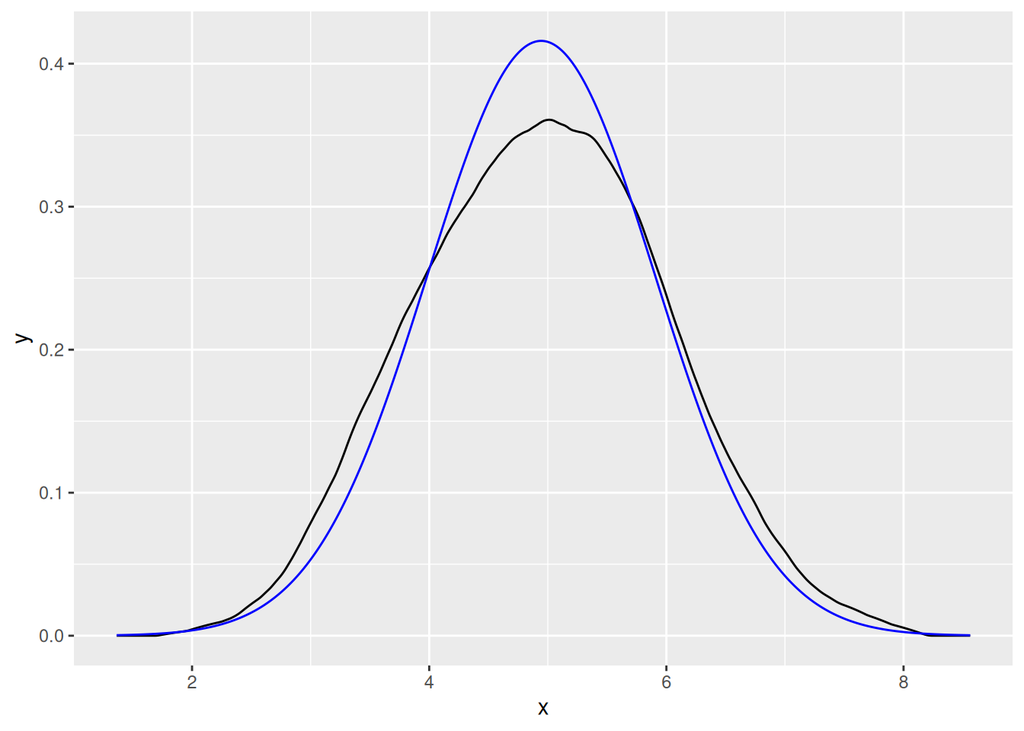

```r
# Completar aquí
# Estimar densidad con núcleo Epanechnikov y ancho de banda SJ
dens_epan_sj <- density(datos, kernel = "epanechnikov", bw = "SJ")

# Crear un data frame para ggplot2
df_dens <- data.frame(
  x = dens_epan_sj$x,
  y_epan_sj = dens_epan_sj$y
)

# Calcular la densidad teórica (normal con media y desv. est. muestrales)
df_dens$y_teorica <- dnorm(df_dens$x, mean = mean(datos), sd = sd(datos))

# Graficar
ggplot(df_dens, aes(x = x)) +
  geom_line(aes(y = y_epan_sj), color = "black", linetype = "solid") +
  geom_line(aes(y = y_teorica), color = "blue") +
  labs(x = "x", y = "y")
```

```r
# Fin Completar aquí
```

# Ejercicio

Vamos a analizar datos del contexto de empresas. Para ello, vamos a considerar los datos que aparecen en el fichero `salarios.sav` donde tenemos 935 observaciones aleatorias de variables que se corresponden con datos de empleados de una gran corporación (Uriel,R y Aldás,J. “Análisis Multivariante aplicado con R”. Ed. Paraninfo). en particular nos vamos a centrar en la variable salario.

Obten el gráfico de la función de distribución empírica de la variable y superponla con la correspondiente gráfica de una la distribución normal con media y varianza las estimadaa partir de los datos. A partir de la gráfica anterior comenta si parece razonable considerar que los datos provienen de una distribución normal.

```r
library(haven)
DATA_DIRECTORY <- "../../data/"
empresa <- read_sav(paste0(DATA_DIRECTORY, "salarios.sav"))
```

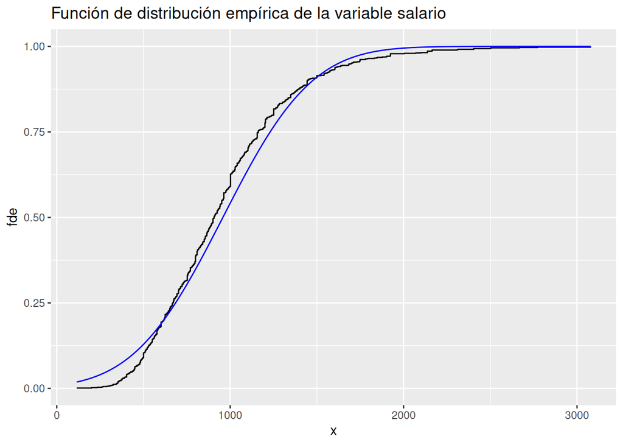

```r
# Completar aquí
salario <- empresa$salario  # Extraer la variable salario

# Calcular la función de distribución empírica
fde_salario <- ecdf(salario)

# Crear un vector de puntos x donde evaluar ambas funciones
x_vals <- seq(min(salario), max(salario), length.out = 1000)

# Evaluar la FDE en esos puntos
y_fde <- fde_salario(x_vals)

# Evaluar la CDF teórica normal (media y desv. est. muestrales)
y_normal <- pnorm(x_vals, mean = mean(salario), sd = sd(salario))

# Crear data frame para ggplot2
df_plot <- data.frame(
  x = x_vals,
  fde = y_fde,
  normal = y_normal
)

# Graficar
ggplot(df_plot, aes(x = x)) +
  geom_step(aes(y = fde), color = "black", linetype = "solid") +  # Escalera (step function)
  geom_line(aes(y = normal), color = "blue") +
  labs(
    x = "x",
    y = "fde",
    title = "Función de distribución empírica de la variable salario"
    )
```

```r
# Fin Completar aquí
```

Obtener la estimaciones tipo núcleo de la función de densidad de la variable anterior, utilizando los núcleos normal y Epanechnikov. Comenta la forma que se obtiene de la función de densidad en cada caso.

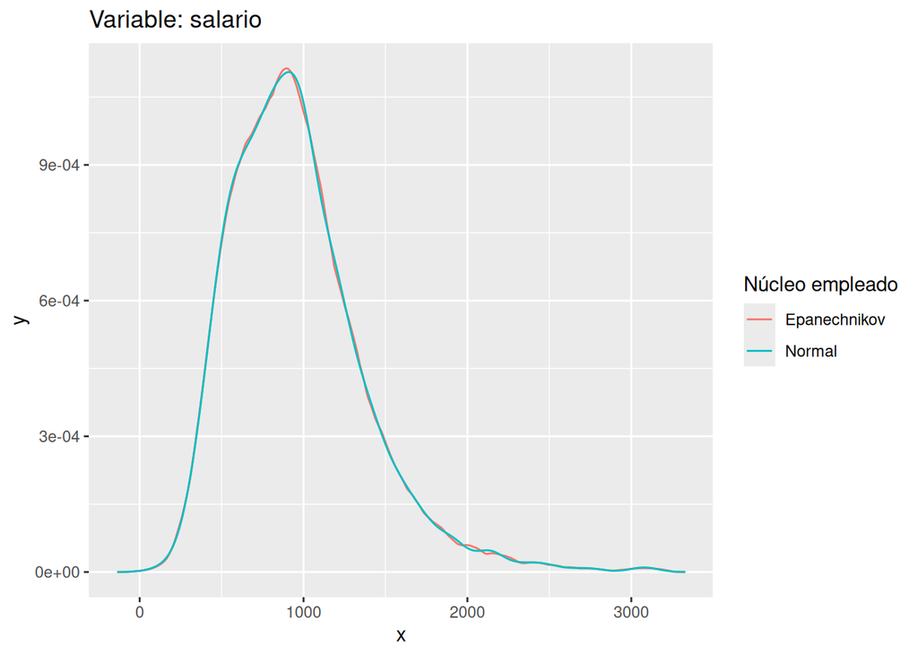

```r
# Completar aquí
library(tidyr)
library(dplyr)
library(stringr)

# Estimar densidades con núcleos normal y Epanechnikov (usando ancho de banda por defecto: 'nrd0')
dens_normal <- density(salario, kernel = "gaussian", bw = "nrd0")
dens_epan <- density(salario, kernel = "epanechnikov", bw = "nrd0")

# Crear data frame con ambos resultados
df_dens <- data.frame(
  x = dens_normal$x,
  normal = dens_normal$y,
  epanechnikov = dens_epan$y
)

# Convertir a formato largo para ggplot2
df_long <- tidyr::pivot_longer(
  df_dens,
  cols = c(normal, epanechnikov),
  names_to = "Núcleo",
  values_to = "Densidad"
) |>
  mutate(
    Núcleo = case_when(
      Núcleo == "normal" ~ "Normal",
      Núcleo == "epanechnikov" ~ "Epanechnikov",
      TRUE ~ Núcleo
    ),
    Núcleo = factor(Núcleo, levels = c("Epanechnikov", "Normal")) # controla orden en la leyenda
  )

# Graficar
ggplot(df_long, aes(x = x, y = Densidad, color = Núcleo)) +
  geom_line() +
  labs(
    title = "Variable: salario",
    x = "x",
    y = "y",
    color = "Núcleo empleado"
  ) +
  theme(legend.position = "right")
```

```r
# Fin Completar aquí
```

Realiza el mismo análisis pero con los datos transformados por el logaritmo neperiano.

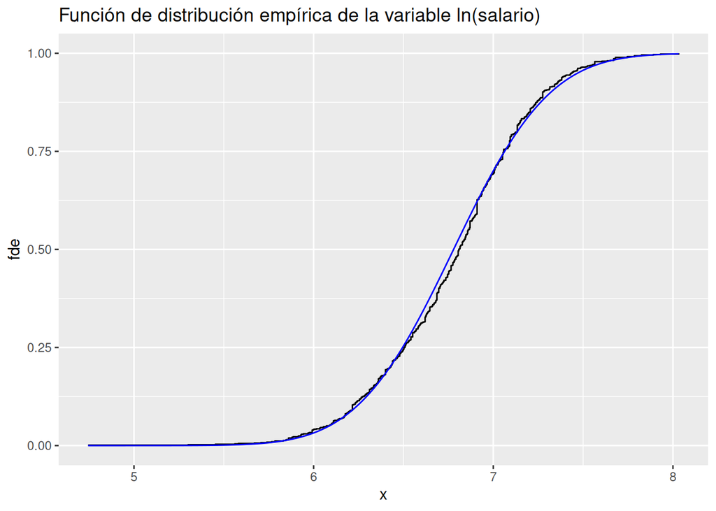

```r
# Completar aquí
salario_pos <- salario[!is.na(salario) & salario > 0]
if (length(salario_pos) == 0) stop("No hay valores positivos en 'salario' para transformar con log().")

log_salario <- log(salario_pos)  # logaritmo neperiano

# Función de distribución empírica
fde_log <- ecdf(log_salario)

# Vector de puntos x donde evaluar ambas funciones
x_vals <- seq(min(log_salario), max(log_salario), length.out = 1000)

# Evaluar FDE y CDF normal teórica (usando media y sd de ln(salario))
y_fde <- fde_log(x_vals)
y_normal <- pnorm(x_vals, mean = mean(log_salario), sd = sd(log_salario))

# Crear data frame para ggplot2
df_plot <- data.frame(
  x = x_vals,
  fde = y_fde,
  normal = y_normal
)

# Graficar
ggplot(df_plot, aes(x = x)) +
  geom_step(aes(y = fde), color = "black", linetype = "solid") +
  geom_line(aes(y = normal), color = "blue") +
  labs(
    x = "x",
    y = "fde",
    title = "Función de distribución empírica de la variable ln(salario)"
    )
```

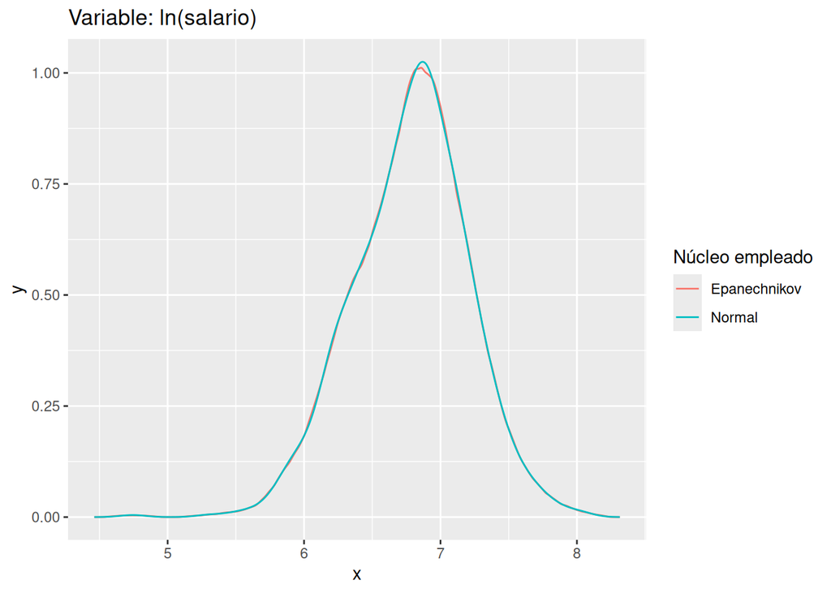

```r
# Estimar densidades sobre ln(salario) con núcleos normal y Epanechnikov (bw = "nrd0")
dens_normal <- density(log_salario, kernel = "gaussian", bw = "nrd0")
dens_epan <- density(log_salario, kernel = "epanechnikov", bw = "nrd0")

# Crear data frame con ambos resultados
df_dens <- data.frame(
  x = dens_normal$x,
  normal = dens_normal$y,
  epanechnikov = dens_epan$y
)

# Convertir a formato largo y normalizar nombres para que coincidan con scale_color_manual
df_long <- tidyr::pivot_longer(
  df_dens,
  cols = c(normal, epanechnikov),
  names_to = "Núcleo",
  values_to = "Densidad"
) %>%
  mutate(
    Núcleo = dplyr::case_when(
      Núcleo == "normal" ~ "Normal",
      Núcleo == "epanechnikov" ~ "Epanechnikov",
      TRUE ~ Núcleo
    ),
    Núcleo = factor(Núcleo, levels = c("Epanechnikov", "Normal"))
  )

# Graficar densidades sobre ln(salario)
ggplot(df_long, aes(x = x, y = Densidad, color = Núcleo)) +
  geom_line() +
  labs(
    title = "Variable: ln(salario)",
    x = "x",
    y = "y",
    color = "Núcleo empleado"
  ) +
  theme(legend.position = "right")
```

```r
# Fin Completar aquí
```